# MCCS G-Formula Nonlinear Simulation 2 Results

Brian Richardson

11/14/2024

```r
rm(list = ls())
library(dplyr)
library(tidyverse)
library(ggplot2)
library(ggh4x)
library(devtools)
load_all()
```

The goal of this program is to evaluate the Monte Carlo corrected score G-formula (MCCS G-FMLA) estimator in the presence of confounding and measurement error and with a nonlinear outcome model.

## Setup

This data generating process leads to a mean potential outcome at $a$ of $\textrm{E}\{Y(a)\} = 0.5 + 0.25a + 0.5a^2 - 0.5a^3$.

The estimand of interest in these simulations is the dose response curve $\{\textrm{E}[Y(a)] : a \in \mathcal{A}\}$.

## Methods

The oracle method uses the true exposure values $A$, which are not observed in practice. The naive method treats $A^*$ as $A$, assuming there is no measurement error. The corrected method uses the Monte-Carlo corrected score versions of the estimating functions, which account for measurement error.

## Results

We first check for simulations with errors.

```r
# load simulation results from each of 10 clusters
sim.out.list <- lapply(
  X = 0:9,
  FUN = function(clust) {
    cbind(clust,
          read.csv(paste0("sim_data/gfmla_nonlinear_2_data/sd",
                          clust, ".csv")))
  })


# combine simulation results into 1 data frame
sim.out <- bind_rows(sim.out.list)

# true estimands
g <- c(0, 0.25, 0.5, -0.5, 1)          # outcome model parameters
a <- seq(-1, 2, length = 20)           # exposure value of interest
EYa.true <- g[1] + 0.5*g[5] + a*g[2] + a^2*g[3] + a^3*g[4]

# number of sims per setting
n.rep <- nrow(sim.out) / n_distinct(dplyr::select(sim.out, n, B, vare))

# make long data frame
sim.out.long <- sim.out %>%
  dplyr::select(!starts_with("a")) %>%
  pivot_longer(cols = starts_with("OG") | starts_with("NG") |
                      starts_with("RG") | starts_with("SG") |
                      starts_with("CG"),
               names_to = "method.aa",
               values_to = "val") %>%
    mutate(method = factor(substr(method.aa, 1, 2),
                           levels = c("OG", "NG", "RG", "SG", "CG"),
                           labels = c("Oracle G-Formula",
                                      "Naive G-Formula",
                                      "Reg. Cal. G-Formula",
                                      "SIMEX G-Formula",
                                      "Corrected G-Formula")),
           aa = as.numeric(gsub("[.]", "", substr(method.aa, 4, 5))),
           a = a[aa],
           EYa.true = EYa.true[aa]) %>%
  dplyr::select(-method.aa)

# make summary data frame
sim.out.summary <- sim.out.long %>%
  group_by(n, vare, B, method, a) %>%
  summarise(bias = mean(val - EYa.true),
            se = sd(val) / sqrt(n.rep),
            bias.lower = bias - qnorm(0.975) * se,
            bias.upper = bias + qnorm(0.975) * se)
```

We first check for simulations with errors.

```r
# summarize proportion of missing data by setting
sim.out.long %>%
  filter(aa == 1) %>%
  group_by(method, n, B, vare) %>%
  summarise(prop.error = mean(is.na(val))) %>%
  filter(prop.error > 0) %>%
  ungroup()
```

```
## # A tibble: 0 × 5
## # ℹ 5 variables: method <fct>, n <int>, B <int>, vare <dbl>, prop.error <dbl>
```

### Plots of Simulation Results

Below is a plot of bias in estimated $\textrm{E}\{Y(a)\}$ over a grid of exposure values.

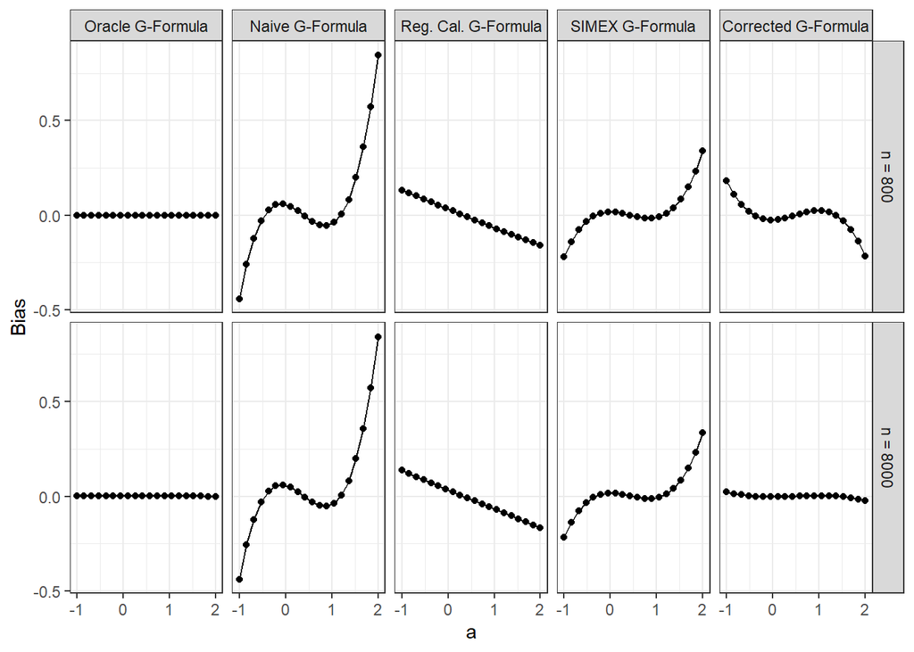

```r
p <- sim.out.summary %>%
  ggplot(
    aes(x = a,
        y = bias,
        ymin = bias.lower,
        ymax = bias.upper)) +
  geom_point() +
  geom_line() +
  facet_grid(n ~ method,
             labeller = labeller(n = function(x) paste0("n = ", x))) +
  theme_bw() +
  theme(legend.position = c(0.2, 0.3)) +
  labs(color = "Method",
       shape = "Method",
       fill = "Method",
       y = "Bias")

p
```

```r
# save plot
ggsave("sim_figures/gfmla_nonlinear_sim_plot.png",
       width = 7,
       height = 4,
       dpi = 300)
```